# Lesson 16 Polyphenols and Grapes (4.2-4.3)

by LTC J. K. Starling

```r
# Load packages
library(tidyverse)
library(ggResidpanel)
```

### Review

Up to this point we have been using statistical models of the form:

we had models of the form:

$${\hat y}_{ij} = \mu + \alpha_i +
\epsilon_{ij} \qquad {\hat y}_{ij} = \mu + \alpha_i + \beta_{j} +
\epsilon_{ij}$$

### Grape Seeds:

Note here our researchers are interested in explaining the variation in the amount of proanthocyanidin (PC) in a grape seed and the sources of the explained variation might be thought of as the percentage of ethanol.

```r
grapes <- read.table("https://raw.githubusercontent.com/jkstarling/MA376/main/Polyphenols.txt", header = TRUE, stringsAsFactors = TRUE)

# setwd("C:/Users/james.starling/OneDrive - West Point/Teaching/MA376/JimsLessons_AY23-1/Block III/LSN16 (4.2.3)/")
# grapes <-read.table("Polyphenols.txt", header = TRUE, stringsAsFactors = TRUE)

grapes <- grapes %>% mutate(Ethanolf = as.factor(Ethanol.))
```

0. Lets plot the data. Plot `PC` vs `Ethanol.`. What do you see?

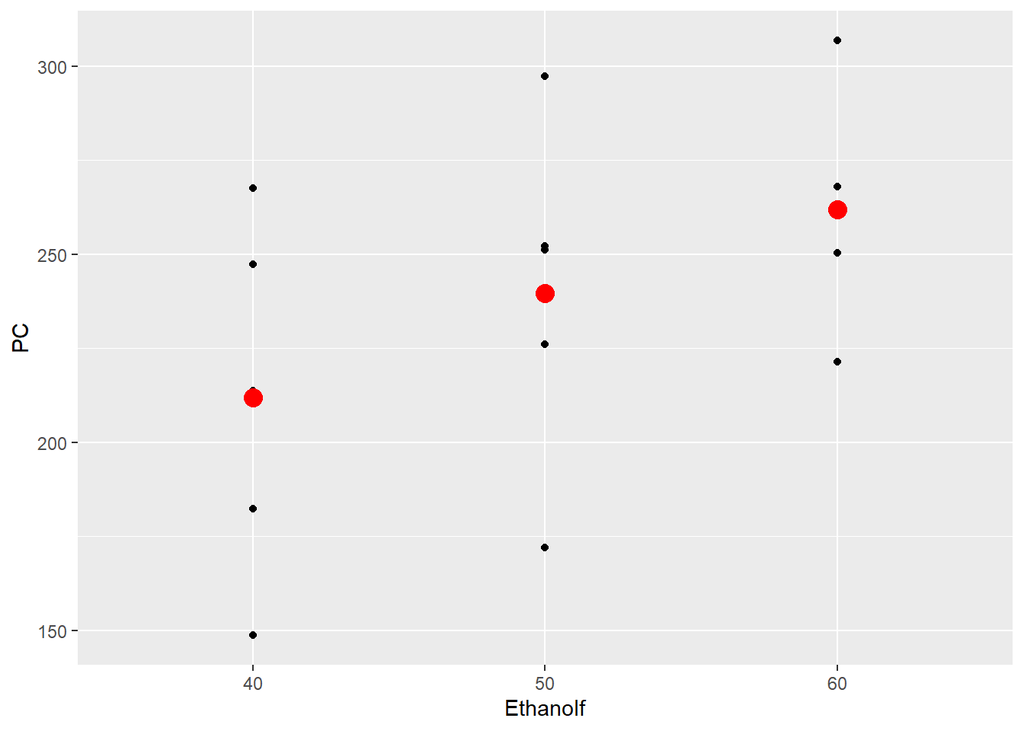

```r
gr.means <- grapes %>% group_by(Ethanolf) %>% summarise(mn = mean(PC))

grapes %>% ggplot(aes(x=Ethanolf, y = PC)) + geom_point() +
  geom_point(aes(x=Ethanolf, y = mn), color="red", size=4, data = gr.means)
```

We can see tha the various levels of ethanol had different means. Let’s check…

1. We can see from the plot that there may be different means for the PC values at different ethanol values. Create a multiple-means model to see if we can determine there is a difference. What can we determine about the results?

```r
contrasts(grapes$Ethanolf) = contr.sum
grape.lm <- grapes %>% lm(PC ~ Ethanolf, data = .)
summary(grape.lm)
```

```
##
## Call:
## lm(formula = PC ~ Ethanolf, data = .)
##
## Residuals:
##    Min     1Q Median     3Q    Max
## -67.74 -21.60   1.84  23.85  57.66
##
## Coefficients:
##             Estimate Std. Error t value Pr(>|t|)
## (Intercept)   237.90      10.91  21.805 5.08e-11 ***
## Ethanolf1     -25.94      15.43  -1.681    0.119
## Ethanolf2       1.84      15.43   0.119    0.907
## ---
## Signif. codes:  0 '***' 0.001 '**' 0.01 '*' 0.05 '.' 0.1 ' ' 1
##
## Residual standard error: 42.26 on 12 degrees of freedom
## Multiple R-squared:  0.2268, Adjusted R-squared:  0.09794
## F-statistic:  1.76 on 2 and 12 DF,  p-value: 0.2137
```

```r
anova(grape.lm)
```

|  | Df | Sum Sq | Mean Sq | F value | Pr(>F) |
| --- | --- | --- | --- | --- | --- |
| Ethanolf | 2 | 6285.396 | 3142.698 | 1.76003 | 0.2136619 |
| Residuals | 12 | 21427.124 | 1785.594 | NA | NA |

It looks like we don’t have strong evidence to reject the null hypothesis that the means are the same.

2. What else could we try…? If our means had a linear relationship, what model could we try? Write down the model here. What is the fitted (or predicted model)?

We could try a linear regression model:

$$y = \beta_0 + \beta_1 x_i +
\epsilon_i$$

$${\hat y}_{i} = \hat\beta_0 + \hat\beta_1
x_i$$

3. Fit the linear model using R. How do we interpret the outcome?

```r
grape.reg.lm <- grapes %>% lm(PC ~ Ethanol., data = .)
summary(grape.reg.lm)
```

```
##
## Call:
## lm(formula = PC ~ Ethanol., data = .)
##
## Residuals:
##    Min     1Q Median     3Q    Max
## -65.90 -21.55   0.92  24.31  59.50
##
## Coefficients:
##             Estimate Std. Error t value Pr(>|t|)
## (Intercept)  112.800     65.081   1.733   0.1067
## Ethanol.       2.502      1.285   1.948   0.0734 .
## ---
## Signif. codes:  0 '***' 0.001 '**' 0.01 '*' 0.05 '.' 0.1 ' ' 1
##
## Residual standard error: 40.62 on 13 degrees of freedom
## Multiple R-squared:  0.2259, Adjusted R-squared:  0.1663
## F-statistic: 3.793 on 1 and 13 DF,  p-value: 0.07338
```

Our beta0 is the intercept; our beta1 is the slope. Since we have a p-value over 0.05, we cannot be sure that the slope is indeed positive.

4. One often overlooked aspect of using regression vs ANOVA is that the linear regression model is actually more restrictive than the separate means model. Compare the anova tables for the regression model with the multiple-means model. How does our $R^2$/residual standard error/SSError compare?

```r
anova(grape.reg.lm)
```

|  | Df | Sum Sq | Mean Sq | F value | Pr(>F) |
| --- | --- | --- | --- | --- | --- |
| Ethanol. | 1 | 6260.004 | 6260.004 | 3.793497 | 0.07337761 |
| Residuals | 13 | 21452.516 | 1650.194 | NA | NA |

```r
anova(grape.lm)
```

|  | Df | Sum Sq | Mean Sq | F value | Pr(>F) |
| --- | --- | --- | --- | --- | --- |
| Ethanolf | 2 | 6285.396 | 3142.698 | 1.76003 | 0.2136619 |
| Residuals | 12 | 21427.124 | 1785.594 | NA | NA |

Note: When we use a regression model vs a separate means model we are making a trade-off. We are actually building a simpler model, but hoping that the additional complexity a multiple means model provides minimal difference in explaining variability. All things being equal we always prefer a simpler model. If we have two models that have similar SSError values, choose the model that uses fewer degrees of freedom. It isn’t always clear whether a separate means model outperforms a linear regression model.

5. The assumption that we are making is that our group means are linearly related to each other. If we have a scientific reason for believing that Ethanol is linearly related to PC than it certainly would be advantageous to use a linear regression model over a group means (or cell means) model.

What is our null and alternative hypothesis under this model?

$H_0$: There is no linear association between ethanol content in the solvent and the amount of proanthocyanidin (PC) recovered in the underlying extraction process.

6. Another way to think about this hypothesis is that we are testing whether the linear regression model explains more variation (statistically speaking) than the null model. Recall that the null model is:

our null model is ($\mu$ is overall mean): $y_i = \mu + \epsilon_{i}$

One statistic that our book starts with that can be used to test this hypothesis is our $R^2$ statistic. Remember that $R^2$ is a measurement of how much of our variation can be explained through our explanatory variables.

If Ethanol didn’t matter ($H_0$ is true) how can we see how rare it would be that we observed our $R^2$?

ANS: SIMULATE!!!

```r
my.rsq <- summary(grape.reg.lm)$'r.squared'

set.seed(376)
M <- 1000
stat <- rep(NA, M)  # create empty vector
for(j in 1:M){
  grapes$eth.shuff <- sample(grapes$Ethanol.)
  shuff.lm <- grapes %>% lm(PC ~ eth.shuff, data = .)
  stat[j] <- summary(shuff.lm)$'r.squared'
}

statt <- data.frame(stat)
```

So… how rare is our observed statistic?

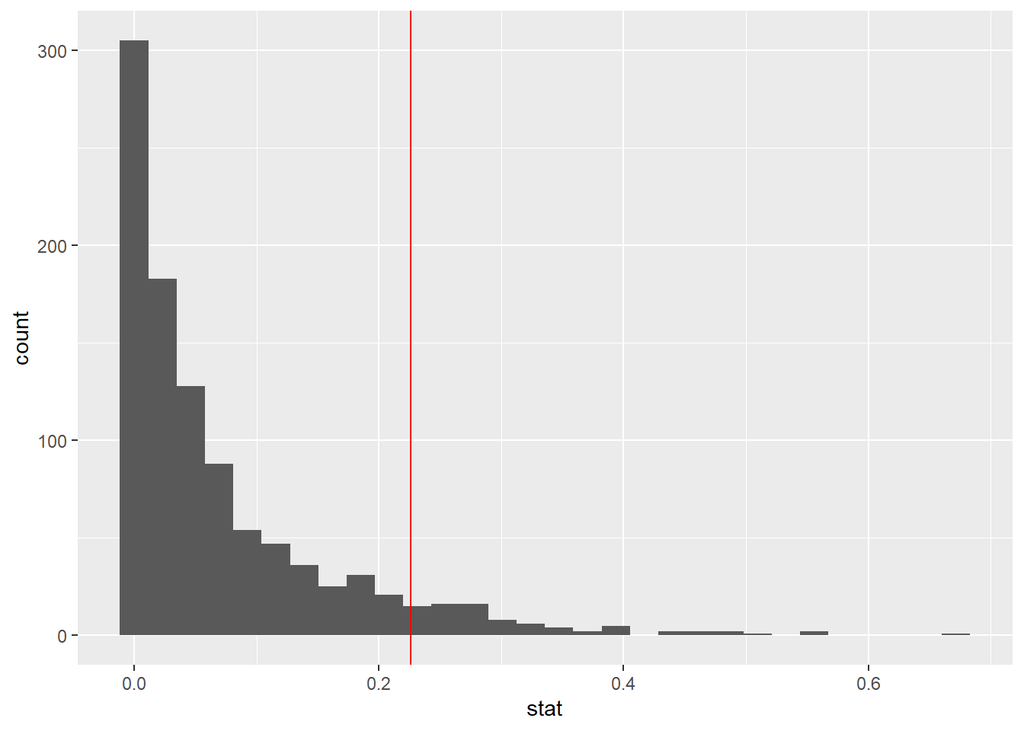

```r
statt %>% ggplot(aes(x=stat)) + geom_histogram() +
  geom_vline(xintercept = my.rsq, color="red")
```

```r
sum(stat >= my.rsq) / M
```

```
## [1] 0.075
```

7. Can we think of a better statistic to use? Write out the null/alternative hypothesis for a different statistic.

$H_0$: $H_0: \beta_1 = 0$

$H_a$: $H_0: \beta_1 \ne 0$

8. Run a simulation to estimate the new statistic. How rare is our statistic? (note: we assume a two-sided test).

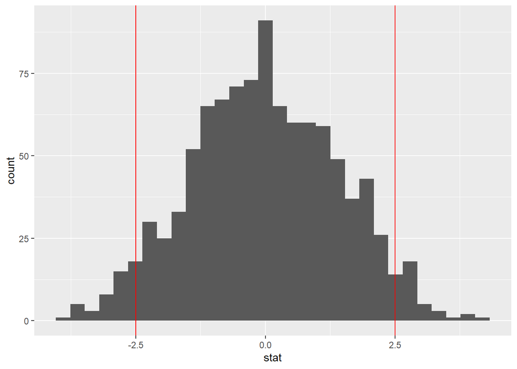

```r
my.beta1 <- unname(coef(grape.reg.lm)[2])

set.seed(376)
M <- 1000
stat <- rep(NA, M)  # create empty vector
for(j in 1:M){
  grapes$eth.shuff <- sample(grapes$Ethanol.)
  shuff.lm <- grapes %>% lm(PC ~ eth.shuff, data = .)
  stat[j] <- coef(shuff.lm)[2]
}

statt <- data.frame(stat)

statt %>% ggplot(aes(x=stat)) + geom_histogram() +
  geom_vline(xintercept = my.beta1, color="red") + geom_vline(xintercept = -my.beta1, color="red")
```

```r
(sum(stat >= my.rsq) + sum(stat <= -my.rsq))/ M
```

```
## [1] 0.864
```

9. Can we estimate an approximate $t-$statistic from the simulation?

$t =$ (sample slope - hypothesized value of slope) / (std. deviation of null distribution of slope) = (2.502 - 0) / 1.418 = 1.764

```r
sd(stat)
```

```
## [1] 1.418243
```

```r
2.502 / sd(stat)
```

```
## [1] 1.764154
```

With a t-statistic of 1.764, it is less than 2 so we don’t have strong evidence to say there is a linear relationship with the PC recovered in the process and the ethanol.

10. But…. if our validity conditions are met, we can actually know the distribution of $\hat\beta_1$. What are the validity conditions?

L - Linearity - the residuals vs. predicted values graph does not show any strong evidence of curvature or other patterns

I - Independence - the responses can be considered independent of each other

N - the responses can be considered independent of each other

E - the residuals vs. predicted values graph shows a constant width

11. Of these, the ones that really matter are outliers and independence (in my opinion), we are relatively robust otherwise. The validity conditions can be wrapped up into $\epsilon_{ij}$… but we can never actually observe these so we can estimate it from the residuals ($r_{ij} = y_{ij} - \hat y_{ij}$). Check the residuals and plot below. Explain what you see.

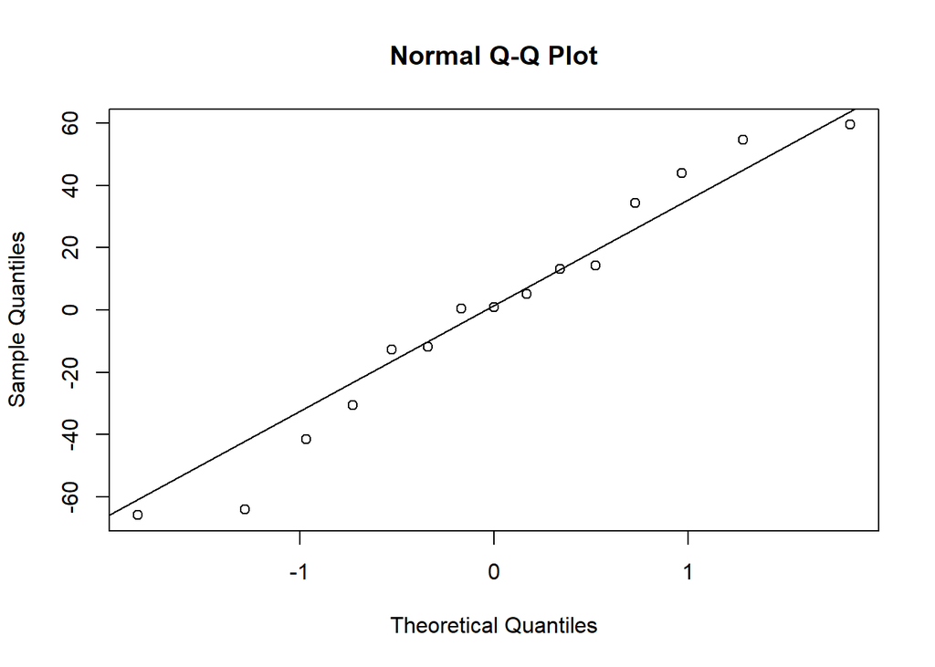

```r
resids <- grape.reg.lm$residuals
yhat <- grape.reg.lm$fitted.values
qqnorm(resids)
qqline(resids)
```

12. What if we use ANOVA? What do we see?

Using the f-stat, calculate the p-value. Can you compare the results of a t-test with the F-statistic from the ANOVA table?

note: $t = \hat\beta_1 / SE(\hat\beta_1)$ where $SE(\hat\beta_1) = SE \; of \; residuals / (\sqrt{n-1} SD(X))$.

```r
anova(grape.reg.lm)
```

|  | Df | Sum Sq | Mean Sq | F value | Pr(>F) |
| --- | --- | --- | --- | --- | --- |
| Ethanol. | 1 | 6260.004 | 6260.004 | 3.793497 | 0.07337761 |
| Residuals | 13 | 21452.516 | 1650.194 | NA | NA |

```r
# f-stat
1 - pf(3.79, 1, 13)
```

```
## [1] 0.07349476
```

```r
pf(3.79, 1, 13, lower.tail = FALSE)
```

```
## [1] 0.07349476
```

```r
# t-stat
se.beta1 <- summary(grape.reg.lm)$sigma / (sqrt(15-1) * sd(grapes$Ethanol.))
my.tstat <- my.beta1 / se.beta1

my.tstat
```

```
## [1] 1.94769
```

13. Finally, we can calculate the confidence interval of $\hat\beta_1$ by

$$\hat\beta_1 \pm t^* (SE \; of \;
\hat\beta_1)$$

```r
tstar <- qt(1-0.025, 13)

c(my.beta1 - tstar * se.beta1, my.beta1 + tstar * se.beta1)
```

```
## [1] -0.2732065  5.2772065
```

```r
# OR

confint(grape.reg.lm)
```

```
##                   2.5 %     97.5 %
## (Intercept) -27.7982917 253.398292
## Ethanol.     -0.2732065   5.277207
```